# Wiretap BadSpeech Experiment Report

Synthesizing New Data by Back Translation

Wiretap Behavioral Intelligence Team

# Objective

The objective of this report is to illustarte the result of synthesizing new message data using back translation techniques.

The motivation of this experiment is to further improve our badspeech model. As discussed in our badspeech-mpr, our current training data size is too small for our model to fully capture the underlying pattern. As currently constructed, the Bad Speech Model returns a set of four scores for each message, which represent probabilities that the message is (1) not inappropriate for work, (2) inappropriate for work but not otherwise problematic, (3) contains speech that could reasonably be seen as offensive, or (4) contains hateful speech. The training data size is especially small in the later three categories.

Here, we proposed a training data augmentation technique called back translation, meaning we translated our labeled messages into foreign languages like Chinese, Spaniash and German and then back translated those messages into English. We expected the back translated messages will be different from original messages, hence increased our training data size.

An illustration of back translation workflow is shown as follows:

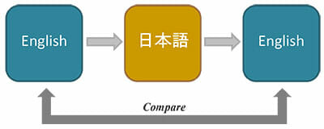

We applied this technique to our current messages in badspeechENG collection in labelstore to increase the training data size and checked whether this manipulation would improve our model performance in this experiment.

# Experiment 1

## Back Translation Augmentation by Chinese

In this experiment, we selected google cloud translatioin api to do the machine translation because of its support on various natural languages and relative low price. The natural language we choosed in this experiment as the intermediate level is Chinese. We assumed the change of messages after back translation transformation will be relatively large since Chinese and English are from two different lanuage families, the former Sino-Tibetan and latter Indo-European.

The data we used are from the badspeechENG collection in our labelstore. Currently it contains 34191 rows of messages. We selected out three categories of messages (1)inappropriate for work (2) offensive (3) discriminative and hateful to do backtranslation because the number of those messages are much lower than the number of not inappropriate messages. Increasing the size of these three categories will make the distribution of four categories of messages more balanced.

In addition, the F score on those categories are still relatively low and still have potential to increase according to the F statistics in the last round of training. 9866 rows of messages were back translated. The data size increased by 28.86% after we applying the back translation technique and distribution of labels is provided in the chart below.

[figure not shown]

## Sampling

The breakdown across train, development, and tests sets is provided in the table below.

Sample Breakdown

|  | Size | Share |
| --- | --- | --- |
| train | 35515 | 0.806 |
| development | 6833 | 0.155 |
| test | 1709 | 0.039 |

## The Model

The model of this experiment is exactly the same as the model we used for badspeech model since we want to control this variable to really investigate the influence of increasing training data size. All detailed information of the model design can be found in the MPR of badspeech model.

# Result

Performance of the model of this experimentation is assessed based on the F1 score on the hold-out dev set. The main comparison benckmark is the generation 3 of badspeech model(referred as ‘BadSpeechG3’ in following text). The comparative performance is shown as below:

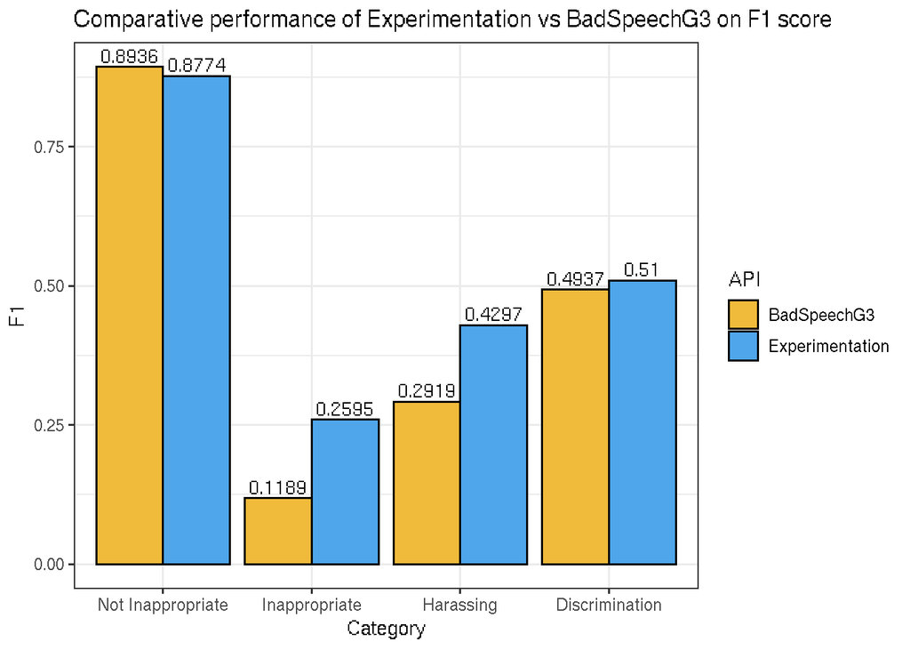

# Experiment 2

## Back Translation Augmentation by German

We designed another experiment using back translation techniques by German to validate whether the increase of model perfomance brought by this technique is sustaintable. The non-offensive messages were not back translated in Experiment 1. Thus,we also randomly selected 2000 messages from not-inappropriate categories and back translated them. This would rule out the influence of other confounding variables. All other procedures remained the same as Experiment1.

We assumed the change of messages after back translation transformation will be relatively large since German has much less vocabluary size than English.

[figure not shown]

## Sampling

There are currently 46053 messages in the dataset. All messages generated by back translation technique are placed into training sets because the purpose of this experiment is to see whether adding those artificial messages can increase our model performance on hold-out development and test set. The rest of messages are randomly sampled into three groups corresponding to training, development, and test sets.

The breakdown across train, development, and tests sets is provided in the table below.

Sample Breakdown

|  | Size | Share |
| --- | --- | --- |
| train | 37511 | 0.815 |
| development | 6833 | 0.148 |
| test | 1709 | 0.037 |

## The Model

The model of this experiment is exactly the same as Experiment 1 above.

# Result

Performance of the model of this experimentation is assessed based on the F1 score on the hold-out dev set. The main comparison benckmark is the generation 3 of badspeech model(referred as ‘BadSpeechG3’ in following text) and the model performance of model using Chinese back translation techniques(referred as ‘Exp-Chinese’ in the following text). The comparative performance is shown as below:

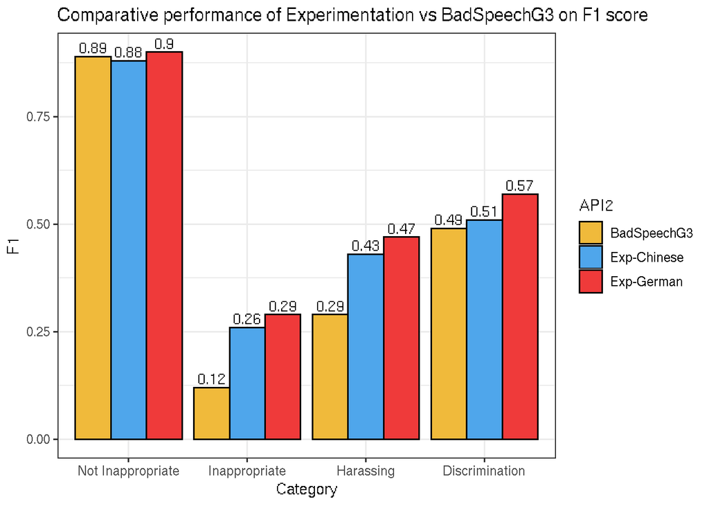

In experiment 2, we can find that the model performance further increase comparing with experiment 1 and benchmark BadSpeechG3 model. This can be attributed to the further increase of data size in all four categories and using different natural language German as the intermediate language.

# Discussion

We clearly find that the performance of two experimentation models improved in classifying various types of messages on our main F1 metrics. This indicates that back translation technique is quite robust for data augmentation and increading model performance in text classficiation tasks in general. One reason for this improvment is Google Translate would make errors in the translation processes, which helped prevent our model from overfitting to irrelevant features.

Specifically, back translation by different natural languages will have different effects on model performance. In our badspeech classification task, using German will improve the model performance more than using Chinese.

The current approach has the following advantages:

- Easily enlarge our training data size with a much lower cost and faster speed than using FigureEight

In this experiment, all emoji features are lost during the process of back translation. This issue needs to be further improved in the next iteration of experiment.

Our next stage of action wil be:

- Bulk this experiment by introducing more intermediate natural language level. We can include Spanish, French, Dutch in furture experiment.